# Tarea 2 Genomica Funcional

Carolina Alvarez

16/2/2022

# Tarea 2. Genomica Funcional

1. Considera las siguientes cantidades discute y justifica que tipo de distribucion de probabilidad pueden tener las siguientes variables:

   *a) El numero (talla) de calzado de adultos varones en Mexico.*

   Distribucion normal o gaussiana porque el promedio residiria en el centro y solo un numero reducido de personas tendria talla de calzado muy grande o muy pequena. Normalmente las caracteristicas humanas siempre tienden a presentar una distribucion gaussiana porque el promedio se concentra en un conjunto de medidas segun la poblacion.

   *b) La distribucion de habitantes en asentamientos humanos de Mexico.*

   Distribucion de cola larga porque hay pocas ciudades muy pobladas en Mexico y hay muchos asentamientos que tienen un numero de habitantes reducido por la diversidad cultural y el cantidad de poblaciones indigenas y municipios que hay en cada estado.

   *c) La velocidad promedio de los automoviles en Bernardo Quintana a las 9 de la manana en un dia laborable.*

   Distribucion logaritmica o poisson, porque la mayoria de los carros va a ir muy lento y algunos que crean que pueden volar sobre el trafico van a acelerar mucho. Como no se explicar pongo la siguiente imagen, considere que en el eje x se ve la velocidad de los automoviles en escala creciente y en el eje y la cantidad de autos. La moda tiende a muchos autos a baja velocidad y pocos a velocidad alta.

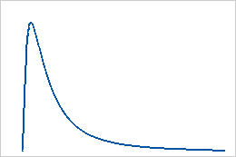

   *d) La velocidad promedio de los automoviles en Bernardo Quintana a las 3 de la manana.*

   Distribucion lineal o exponencial. Puede ser lineal porque la velocidad se mantiene constante entre todos los conductores. Tambien puede ser exponencial porque al entrar en Bernardo Quintana y ver que a las 3am esta despejado el camino puedes ir aumentando la velocidad conforme avanzas.
2. Supongamos que tenemos dos nodos (A,B) en una red. El nodo A y B tiene el mismo degree, pero el A tiene un coeficiente de clusterizacion de 1 y el nodo B un coeficiente bajo. Dibuja esta situacion y explica cual seria una mejor diana si quieres eliminarlos y afectar a la red.

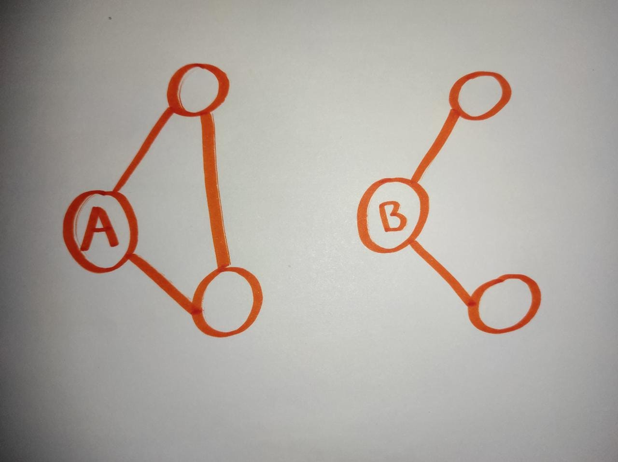

A y B tienen el mismo numero de conexiones (2), pero A tiene un coeficiente de clusterizacion de 1 porque todos los nodos alrededor de A estan conectados. En B su coeficiente es menor porque no esta completamente conectado. Se afectaria mas la red si retiramos el nodo B porque este es el nodo que une a sus vecinos, en cambio si quitamos A los vecinos permanecen unidos.

3. Elabora un programa en R que usando funciones calcule, a partir de una matriz de adyacencia (Solo utiliza R base para resolver este problema).
   1. Si la red es dirigida o no.
   2. Si la red es pesada o no.
   3. El degree de los nodos.
   4. El histograma del degree.

```r
#Si es o no dirigida depende de si al multiplicar los elementos de la matriz de adyacencia el valor no es igual
direction <- function(){
matriz <- read.csv("matriz.csv")
x <- matriz[2,3]
y <- matriz[3,2]
mul <- y*x
mul1 <- x*y
dirigida <- if(mul== mul1){
  print("Es no dirigida")
}else{print("Es dirigida")}
}

#Una red es pesada si hay mas de una conexion entre los nodos
pesored <- function(){
matriz <- read.csv("matriz.csv")
pesada <- if(matriz==1){
  print("No es pesada")
}else{print("Es pesada")}
}

#Calculo del numero de conexiones por cada nodo
degreeR <- function(){
matriz <- read.csv("matriz.csv")
A <- matriz[1,-1] #separar cada renglon
B <- matriz[2,-1]
C <- matriz[3,-1]
D <- matriz[4,-1]
E <- matriz[5,-1]
eF <- matriz[6-1]

sumA <- sum(A) #sumar cuantas conexiones tiene cada nodo
sumB <- sum(B)
sumC <- sum(C)
sumD <- sum(D)
sumE <- sum(E)
sumF <- sum(eF)

#juntar las sumas en un vector
deg <- c(sumA, sumB, sumC, sumD, sumE, sumF)
names(deg) <- c("A","B","C","D","E","F") #asignar nombres de identificacion
histdeg <- hist(deg) #hacer el histograma
}
```

4. A partir de la red de interaccion de proteinas alojada en la libreria igraphdata, que puedes llamar mediante data(yeast) elabora un programa en R (aca si puedes usar librerias especializadas de R) que:

```r
#Cargar o instalar las siguientes librerias
library(igraph)
library(igraphdata)
```

1. *Calcule la distribucion de conectividades y grafique esa distribucion . Discute tu resultado.*

```r
#Cargar la base de datos "yeast"
data("yeast")
#Calcular la distribucion de conectividades entre nodos
distribuciones <- degree.distribution(yeast)
#Generar un plot de la distribucion
plot(distribuciones, main="Degree distribution", xlab="Degree", ylab="Frequency")
```

[output not shown]

La distribucion del numero de conexiones entre nodos de la red es de cola larga. Las redes biologicas tienen a tener distribucion tipo free-scale que forman una cola larga porque hay nodos con grados de conectividad muy alto (hubs como reguladores maestros) y otros con muy poca conectividad. Esto quiere decir que en esta red de proteinas hay algunas que regulan la funcion de muchas otras.

*b. Grafique el boxplot de la distribucion de conectividades y discute tu resultado.*

```r
#Boxplot de la distribucion de conectividades
boxplot(distribuciones)
```

[output not shown]

La mayoria de los estan concentrados en valores de frecuencia menores, y solo un numero reducido de nodos presentan frecuencias elevadas. Estos ultimos pueden ser hubs (nodos con alta conectividad) y por lo tanto son proteinas importantes en la red.

*c. Encuentre la proporcion de nodos que tienen 15 o mas conectividades.*

```r
#Calcular el numero de conexiones
con <- degree(yeast)
#convertirlo a vector
convec <- as.vector(con)
#tabla de frecuencia
contab <- table(convec)
#ordenar las frecuencias de mayor a menor
contab <- sort(contab, decreasing = TRUE)
#convertir a vector
as.vector(contab)
#calcular el total de conexiones en la red
suma <- sum(contab)
#seleccionar los nodos con 15 o mas conexiones
mayores <- contab[1:23]
#calcular el total de conexiones de los mayores o iguales a 15
sumamayores <- sum(mayores)
#CALCULO DE PROPORCION
proporcion <- sumamayores*100/suma
```

*d. Calcule el degree maximo de la red.*

```r
#Calcular el degree
dg <- degree(yeast)
#Ordenar de mayor a menor el numero de conexiones
sort(dg, decreasing = TRUE)

#El degree maximo es de 118 conexiones
```

*e. Calcule el diametro*

```r
#Diametro = 15
diameter(yeast)
```

*f. La trayectoria mas larga.*

```r
distances(yeast)
```

*g. Elimine los 10 nodos mas conectados de la red y determine el diametro cada vez que lo haga.*

```r
#Diametro cero: 15
diameter(yeast)
#Diametro uno: 17
uno <- delete.vertices(yeast, 610)
diameter(uno)
#Diametro dos: 15
dos <- delete.vertices(yeast, 1131)
diameter(dos)
#Diametro tres: 15
tres <- delete.vertices(yeast, 184)
diameter(tres)
#Diametro cuatro: 15
cuatro <- delete.vertices(yeast, 154)
diameter(cuatro)
#Diametro cinco: 15
cinco <- delete.vertices(yeast, 1007)
diameter(cinco)
#Diametro seis: 15
seis <- delete.vertices(yeast, 1030)
diameter(seis)
#Diametro siete: 15
siete <- delete.vertices(yeast, 252)
diameter(siete)
#Diametro ocho: 15
ocho <- delete.vertices(yeast, 6)
diameter(ocho)
#Diametro nueve: 15
nueve <- delete.vertices(yeast, 2131)
diameter(nueve)
#Diametro diez: 15
diez <- delete.vertices(yeast, 280)
diameter(diez)
```

*h. Determine los diez nodos mas importantes por al menos tres medidas de centralidad.*

```r
#Centralize a graph according to the betweenness of vertices
betw <- centr_betw(yeast) #calcular la medida
betw <- as.vector(betw$res) #convertir a vector
names(betw) <- c(1:2613) #identificar cada nodo por numero
sort(betw, decreasing = TRUE) #ordenar por medida

#Centralize a graph according to the degrees of vertices
de <- centr_degree(yeast)
de <- as.vector(de$res)
names(de) <- c(1:2613)
sort(de, decreasing = TRUE)

#Centralize a graph according to the closeness of vertices
clo <- centr_clo(yeast)
clo <- as.vector(clo$res)
names(clo) <- c(1:2613)
sort(clo, decreasing = TRUE)
```

*i. Clusterizar la red por al menos dos metodos y determinar el tamano del cluster mas grande.*

```r
#Metodo 1: Community structure via greedy optimization of modularity
cluster1 <- cluster_fast_greedy(yeast)
table(membership(cluster1)) #tamano de los clusters
#el tamano del cluster mas grande es de 744 nodos

#Metodo 2: Infomap community finding
cluster2 <- cluster_infomap(yeast)
table(membership(cluster2)) #tamano de los clusters
#El tamano del cluster mas grande es de 291 nodos.
```

*j. Determine si la red es de mundo pequeno, ultra pequeno u otra.*

```r
mean_distance(yeast)
transitivity(yeast)
```

Tengo dos opciones de interpretacion porque no recuerdo cual es la correcta:

- La media de la distancia entre los nodos de la red es de 5.095629 conexiones por nodo. No es una red de mundo pequeno porque necesitaria ser un valor cercano a 1 si asi fuera.
- El coeficiente de clusterizacion es 0.468617 por lo que es una red de mundo pequeno.

[figure not shown]